# CIS3521 B Final Project: Mangrove Tree Data Analysis

Flagler College 2026

Author

Ava Mariano, Jazmine Major, Gavin Hines

# 1. Introduction

Our data set came from a Flagler senior Capstone project involving the sampling of Mangrove trees from seven distinct sites, which were anayzed at the University of Hawai’i at Hilo’s Analytical Labratory. Data included in the labratory test results which we chose to analyze were the sample ID’s and their % of Organic Matter (OM), Nitrogen (N), and Carbon (C).

# 2. Data Cleaning

We extracted a number of raw data columns from capstone excel sheet and entered the information into a new excel sheet for easier cleaning. Column names were changed to lower snake case, NA columns were removed, names were corrected and made uniform (e.g. `percent_c` -> `c_percent`), and `species` and `site` columns were created using `mutate()`. Typos and spacing errors were fixed, and superfluous comments from original athors were removed (e.g. “Very Shelly” written in `weighboat_code`). Typos and comments were fixed using `str_replace_all` and `str_remove`, furthermore, in creating new columns, `str_start` and `str_detect` were found in Tidyverse’s `stringr` package documentation.

```r
library(tidyverse)

library(janitor)

library(readxl)

library(tinytable)

library(ggpubr)


plant_material_samples <- read_csv("/Users/gavinhines/Documents/CIS351 B 2026 Spring/Data/Final_Project_Data(Sheet1).csv")

plant_material_samples <- clean_names(plant_material_samples)

plant_material_samples <- plant_material_samples |>
    rename(
        weighboat_code = weigh_boat_code,
        c_percent = percent_c,
        n_percent = percent_n
    )

plant_material_samples_2 <- plant_material_samples |>
    filter_out(is.na(weighboat_code))

plant_material_samples_3 <- plant_material_samples_2 |>
    mutate(
        weighboat_code = str_replace_all(weighboat_code, "FBI", "FRI"),

        weighboat_code = str_remove(weighboat_code, "-.*$"),
        # looked this up: what its doing is removing all characters after the hyphen no matter what it is continuously until the end of the string ($). This was to remove the extra comments left in .xslx file
        weighboat_code = recode(weighboat_code, "BTOY2A" = "B TOY 2A")
    )
```

C and N % were calculated using OM% in a formula. These formulas required OM as a decimal, but it seems capstone students used a %. It is unknown what errors were made with the output of these formulas, but it probably involved improper unit conversion. By researching normal C and N % of mangrove trees, we were able to modify the results of the formulas to bring them into realistic ranges. The exact formulas they used were extracted from the capstone excel sheet.

```r
plant_material_samples_4 <- plant_material_samples_3 |>
    mutate(
        #creating 'species' categorical variable from 'weighboat_code'
        species = case_when(
            str_starts(weighboat_code, "R") ~ "Red Mangrove",
            str_starts(weighboat_code, "B") ~ "Black Mangrove"
        ),
        # creating 'site' categorical variable from 'weighboat_code'
        site = case_when(
            str_detect(weighboat_code, "SUN") ~ "SUN",
            str_detect(weighboat_code, "MON") ~ "MON",
            str_detect(weighboat_code, "TAN") ~ "TAN",
            str_detect(weighboat_code, "LOB") ~ "LOB",
            str_detect(weighboat_code, "TOY") ~ "TOY",
            str_detect(weighboat_code, "STR") ~ "STR",
            str_detect(weighboat_code, "FRI") ~ "FRI"
        ),
        # capstone students used formulas and did not use the proper units, that's why N% is sometimes listed > 700%
        c_percent = ((0.2385 * om_percent) + 0.7742) * 10, # to make % match normal mangrove levels
        n_percent = ((16.962 * om_percent) - 0.3475) / 100 # from g/kg to %
    )
```

# 3. Descripitive Statistics

We provide summary statistics for the numerical variables: `om_percent`, `c_percent`, and `n_percent`. For the categorical variables, we measured summary statistics for `species` and `site`.

# 3.1 Summary Stats for `species`

```r
plant_material_samples_4 |>
    filter(!is.na(species)) |>
    summarize(
        Count = n(),
        .by = species
    ) |>
        tt()
```

| species | Count |
| --- | --- |
| Red Mangrove | 60 |
| Black Mangrove | 66 |

# 3.2 Summary Stats for `site`

```r
plant_material_samples_4 |>
    filter(!is.na(site)) |>
    summarize(
        Count = n(),
        .by = site
    ) |>
        tt()
```

| site | Count |
| --- | --- |
| SUN | 15 |
| MON | 21 |
| TAN | 18 |
| LOB | 18 |
| TOY | 18 |
| STR | 18 |
| FRI | 18 |

# 3.3 Summary Stats for `om_percent`

```r
plant_material_samples_4 |>
    filter(!is.na(om_percent) & om_percent > 0) |>
    summarize(
        min_om = min(om_percent),
        median_om = median(om_percent),
        mean_om = round(mean(om_percent), 1),
        max_om = max(om_percent),
        sd_om = round(sd(om_percent), 1)
    ) |>
    tt()
```

| min_om | median_om | mean_om | max_om | sd_om |
| --- | --- | --- | --- | --- |
| 1.796889 | 9.943196 | 16.2 | 73.14936 | 17 |

# 3.4 Summary Stats for `c_percent`

```r
plant_material_samples_4 |>
    filter(!is.na(c_percent) & c_percent > 0) |>
    summarize(
        min_c = min(c_percent),
        median_c = median(c_percent),
        mean_c = round(mean(c_percent), 1),
        max_c = max(c_percent),
        sd_c = round(sd(c_percent), 1)
    ) |>
    tt()
```

| min_c | median_c | mean_c | max_c | sd_c |
| --- | --- | --- | --- | --- |
| 12.02758 | 31.45652 | 46.3 | 182.2032 | 40.4 |

# 3.5 Summary Stats for `n_percent`

```r
plant_material_samples_4 |>
    filter(!is.na(n_percent) & n_percent > 0) |>
    summarize(
        min_n = min(n_percent),
        median_n = median(n_percent),
        mean_n = round(mean(n_percent), 1),
        max_n = max(n_percent),
        sd_n = round(sd(n_percent), 1)
    ) |>
    tt()
```

| min_n | median_n | mean_n | max_n | sd_n |
| --- | --- | --- | --- | --- |
| 0.3013133 | 1.68309 | 2.7 | 12.40412 | 2.9 |

# 4. Data Visualizations

## 4.1 Stacked Bar Chart of `species` and `site`

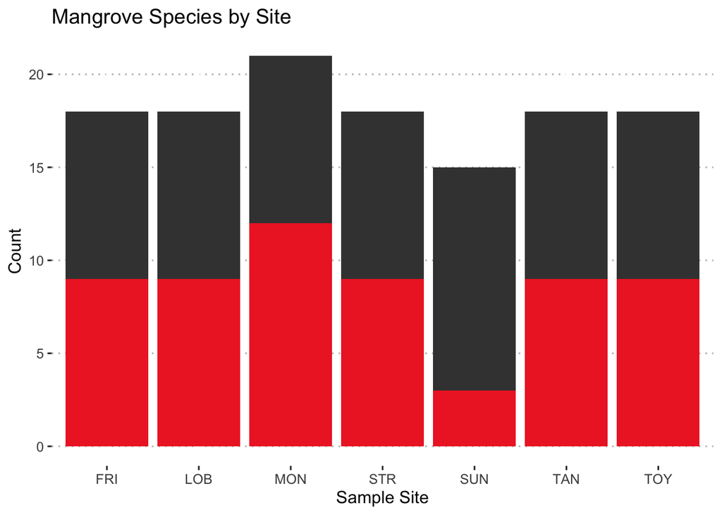

```r
plot_om_bar_2 <- plant_material_samples_4 |>
  filter(!is.na(species)) |>
  ggplot(aes(x = site, fill = species)) +
  geom_bar() +
  scale_fill_manual(values = c("Red Mangrove" = "firebrick2", "Black Mangrove" = "grey25")) + # to specifically choose colors of species
  labs(
    title = "Mangrove Species by Site",
    x = "Sample Site",
    y = "Count"
  ) +
    theme_pubclean() +
    theme(legend.position = "none") # color legend woud be redundant


plot_om_bar_2
```